# CAT UX and item difficulty

Where the LEVANTE CATs sit, what that costs, and where children check out

Author

Vlad Chituc

Published

August 25, 2026

**WarningPreliminary & unvetted**

Analyses were built with AI assistance and have not been reviewed by anyone else. Everything traces to the numbered scripts in `scripts/` and their results JSON. The longer version of the targeting argument is `cat-ux-success-rate-targeting.qmd`.

# Purpose and scope

Two questions. **How hard should a LEVANTE task be?** Maximum-information selection is the psychometric default, but it is not obviously right for a 5-year-old an hour into a battery, three waves deep. And **what does the miss cost?** — in reliability, the currency the core-tasks manuscript reports, not in abstract information units, and in whether the child stays engaged at all.

This document takes those two questions to the pilot data: where each deployed CAT sits against its own information optimum, what the misses cost in three currencies, why Pattern Matching’s is the worst (its item bank), where the CAT starts every child, where children check out, and the same problem one age band down in the math downward extension.

Stakes: ~1 hour of core battery per wave, minimum three waves per child, ages 5–12, three sites.

**NoteTerms used throughout (click to expand)**

- **$\theta$ (theta)** — a child’s estimated ability, in **logits** (log-odds units). 0 is the calibration-sample average; −2 is well below average.
- **$b$ (item difficulty)** — on the same logit scale as $\theta$. A child with $\theta = b$ has a 50% chance of a correct answer *before* adding any guessing floor.
- **$g$ (guessing floor)** — the probability of answering correctly by guessing, 1/(number of options). It sets the *lowest* possible accuracy on an item, and it is why the information optimum is not 50%.
- **Fisher information** — how much a single item tells you about $\theta$. More information means a smaller standard error on the child’s score. It is the quantity a CAT maximizes.
- **CAT** — computerized adaptive test. After each response it re-estimates $\theta$ and picks the next item accordingly.
- **MFI (Maximum Fisher Information)** — the standard rule for choosing that next item: pick whichever available item is most informative at the current $\hat\theta$. This is what LEVANTE’s CATs use.
- **Expected accuracy** — for a given child on a given item, the model-predicted probability of a correct answer: $g + (1-g)\,\mathrm{logistic}(a(\theta-b))$. At the trial level it is the main predictor in this document. Distinct from **realized accuracy**, which is what the child actually scored.
- **NT10** — the rapid-guessing threshold used here (Wise & Ma 2012, “normative threshold, 10%”): a response counts as a rapid guess if it arrives faster than **10% of that item’s mean response time** across all children, with a floor of 250 ms and a cap of 10 s. It matters because rapid guesses score at chance and so violate the measurement model — they are noise entered as data.
- **Run fixed effects** — a separate intercept per run, so a comparison is made *within* one child’s single sitting: ability, site, epoch, age, and the child’s overall rate are held fixed by construction.
- **Within-run position** — how far through the run a trial falls (0–1), entered as a cubic; separates “after failures” from “late in the run”.
- **BH correction** — Benjamini-Hochberg, controls the false-discovery rate when many tests are run at once. Every p-value reported per-cell here is BH-adjusted within its family.

# Review of relevant existing work

**NoteReview of relevant existing work**

## Eggen & Verschoor (2006) — what “easy-biased CAT” is, in full

*Optimal testing with easy or difficult items in computerized adaptive testing.* Applied Psychological Measurement 30(5), 379–393. Free as Cito Report 2004-2.

**The setup.** A CAT selects the item with the most Fisher information at the current ability estimate. Under 1PL or 2PL — **models with no guessing parameter** — information is maximized exactly where the examinee has a **50% chance** of being correct. Their words: psychometrically optimal selection means each student always gets items on which they have “a 50% probability of answering correctly.” (The empirical precursor is Bergstrom, Lunz & Gershon 1992, which altered the difficulty targeting of a live CAT with adult examinees.)

**ImportantAre we reinventing the wheel? No — two reasons**

**Their closing paragraph is our bank proposal.** Verbatim: “knowing the effect of selecting with other success probabilities in mind, one could, for CAT applications, build item banks which are more suitable for that purpose… If one knows, for instance, that one wants an easy CAT, one could try to construct a bank which is, on average, easier for the population.”

**Their final sentence names our exact case as unstudied.** “Knowing that the symmetry disappears, it is worthwhile investigating the application of the selection method if the 3pl model, including a guessing parameter, is used.” LEVANTE calibrates every multiple-choice task **with a fixed guessing floor**.

And the whole paper is a simulation. Nobody has measured whether easier targeting changes what a child does.

## Jansen et al. (2013) — the only randomized success-rate experiment in children

*The influence of experiencing success in math on math anxiety, perceived math competence, and math performance.* Learning and Individual Differences 24, 190–197.

**Design.** N = 207, grades 3–6, stratified random assignment to a no-program control plus Math Garden at targeted success rates of **60 / 75 / 90%**. Six weeks, 4 × 15 min per week, ~50 per condition.

**The engine is not a CAT in our sense.** Math Garden runs an **Elo rating system** (Klinkenberg, Straatemeier & van der Maas 2011) — person and item ratings update after every response, on the fly, no pre-calibration. Scoring uses a high-speed-high-stakes rule combining accuracy *and* response time, $S = (2x-1)(d-t)$, 20-second limit. Item selection then samples at the assigned target probability. The deployed default is .75, “challenging yet not too difficult.”

**Results.** “The higher the pre-set success rate, the more problems were attempted, and the larger the improvement in math performance” — **mediated by practice volume**. Performance improved only in the experimental conditions. **Math anxiety improved equally in every condition including the no-program control**; perceived-competence gains were modest.

**Corroboration.** Hilz et al. (2023, *J Intelligence*): N = 376 German fifth-graders, ~20.7 weeks. Practice volume predicted subtraction performance; Math Garden improved self-concept vs wait-list ($\beta$ = .12, p = .002, small); **practice volume did not predict self-concept or anxiety**, corroborating the affective null.

**Caveat.** The Jansen full text is paywalled; per-condition Ns, effect sizes and mediation coefficients are unverified.

**TipHow their randomization compares to ours**

|  | Jansen et al. 2013 | An easier-targeting arm in LEVANTE |
| --- | --- | --- |
| Arms | Control + 60 / 75 / 90% | Success-rate sweep above the information optimum |
| Engine | Elo, on-the-fly, RT in the score | Fixed calibrated bank, MFI with a constraint |
| Purpose | Adaptive **practice** (learning) | Adaptive **measurement** (estimation) |
| Dose | 6 weeks, semi-free volume | One task per wave, time-capped |
| Primary outcome | Math performance gain | Realized success; SE($\theta$); engagement |
| n | ~50 per condition | ~140 per sweep point, ~1,400 for the curve |

**The structural difference that matters:** Jansen’s mechanism is *dose* — more success → more problems attempted → more learning. **LEVANTE’s testing time is fixed** (Pattern Matching is capped at 6 minutes), which largely closes that channel, so their dose-mediated result should not be expected to reproduce here.

## Wise & DeMars (2006) — effort-moderated IRT

*Journal of Educational Measurement* 43(1), 19–38.

**The model.** Classify each person × item encounter as solution behaviour or rapid guess by an item-specific RT threshold, then fit IRT to solution behaviour only — rapid guesses coded *not administered*. A rapid guess contributes a constant to the likelihood, so it does not move where the likelihood peaks; the model drops into standard software unchanged.

**Rates.** Study 1: 1,332 of 23,160 encounters (**5.8%**). Study 2 simulated 2.3% / 6.7% / 11.3% conditions.

Ignoring even that ~6% of disengaged responding distorted the item calibration itself. Discrimination estimates came out about **40% too high on average**, and the bias in difficulty was concentrated where it hurts most: the **easiest third of items appeared 0.79 logits harder than they truly were**. Those are exactly the items a friendly-targeting CAT depends on, and exactly what Pattern Matching’s bank is short of. (The same contamination concern has since been carried into knowledge-tracing models — Gorgun & Bulut 2023.)

## Brinkhuis et al. (2018) — contamination at scale in an easy system

*Journal of Learning Analytics* 5(2), 29–46.

**Children choose their own difficulty** — easy (~90%), medium (~75%, default), hard (~60%) — and the system explicitly does **not** use maximum-information selection: “no optimal item selection is currently attempted.” Measurement efficiency is traded for motivation by design.

**A fifth of responses are contaminated anyway.** Mixture analysis of one day — **463,729 responses, 13,608 students, 10,983 items, 17 games** — found **21% of responses** in a misfit component consistent with fast guessing and typing errors. Even at a .75 target, in the friendliest large-scale child system that exists, one response in five is not measuring what it should. Easy targeting does not remove the need for response-level screening.

## Wise & Kong (2005); Wise & Kingsbury (2016)

Response Time Effort: reliability $\alpha$ = .97, correlating .54 with test performance but **.06 with SAT-V** — it measures effort, not ability. Rapid guesses scored at chance (28.7% vs 24.7% expected). Filtering to RTE $\geq$ .90 raised the test–SAT-V correlation from **.50 to .58** despite dropping 35 examinees. Wise & Kingsbury showed effort-moderated scoring improved accuracy and person fit on an operational adaptive test, and proposed effort-guided CAT — the source of the mistargeting-loop argument.

## Fast and slow errors (sequential-sampling models)

One background fact worth stating: in speeded-decision models (Ratcliff & Rouder 1998), whether errors are *faster* or *slower* than correct responses is a function of the difficulty regime and response caution, not of effort. Fully engaged responders produce **fast errors on easy material** (lapses, premature responses) and **slow errors on hard material**. Any error-vs-correct RT contrast therefore has to be read against the difficulty of the material it was computed on.

## Gamification, and measuring children’s experience

Lumsden et al. (2016), 33 studies: verbatim “no evidence to support that gamified tests can be used to improve data quality,” some indication it worsens it, while intrinsic motivation improved in every study that measured it. Points shift **speed, not accuracy** (Attali & Arieli-Attali 2015); points plus feedback *increased* RT and error rate while increasing positive affect (Wiley, Vedress & Mandryk, CHI 2020 — see below); narrative made game-based assessments **less** likely to correlate with traditional measures (2023 *Progress in Brain Research* review, 378 correlations). Safe zone: cosmetic wrapper, no performance-contingent mechanics — which is what ROAR already does.

## Measuring what children think of the task

If we add a self-report measure this is the instrument family to use, so it is worth knowing what it actually is.

**The Fun Toolkit** (Read 2008, *Cognition, Technology & Work* 10(2), 119–128) is three instruments designed for children, two of which matter here.

- **The Smileyometer** is a five-point scale rendered as cartoon faces, from “Awful” to “Brilliant,” administered immediately after an activity. It is visual rather than verbal, which is the point — pre-readers can use it and it takes seconds. It is by far the most-used child UX measure: a systematic review found **87 of 129 papers** used it, mostly with ages 6–11.
- **The Again-Again table** asks, for each activity, “would you do it again?”, with three options — **yes / maybe / no**. It measures *endurability* rather than momentary enjoyment, which makes it the closer analogue of the outcome we actually care about: whether the child comes back at the next wave.

**The ceiling concern and its current status.** The original worry was acquiescence — children say everything is brilliant. Read’s primary datum (Read & MacFarlane 2006; 47 children aged 7–9, 26 aged 12–13) found **more than 40% of the younger children gave every activity the same score**, against under 10% of the older ones, with means of 3.86 and 3.49.

**Read & Horton (2025)** (*Interacting with Computers*, doi 10.1093/iwc/iwaf016) walk that back. In their case study only **4 of 135 children aged 8–11 (3%)** gave the top rating to all three games, and children as young as 3–4 completed it with adult support (117 of 127 usable pairs). The instrument discriminates better than its reputation suggests — but the age gradient in the original finding still stands, and LEVANTE’s lower band is exactly where flattening was worst.

**Implementation guidance**: use **calibration questions** first (a warm-up such as “how much do you like ice cream?” so the child anchors the scale before rating anything that matters), administer **spoken** for pre-readers, and **counterbalance activity order**.

**ImportantThe order effect might not be an instrument artifact — and that matters**

Read & Horton report the same activity rated **3.95 when it comes first and 3.33 when it comes third**. The standard reading is contamination: an anchoring or contrast artifact, to be removed by counterbalancing.

There is a second reading — that **children genuinely enjoy the third task less than the first**, and the rating is picking up real declining engagement across a session rather than a scale artifact.

**Our own behavioural data favours the second reading, at least in part.** Rapid guessing rises through a run even with item ordering accounted for, and its served-success sensitivity strengthens later in the battery (the battery-position interaction on rapid guessing is the one that survives correction — with the caveat that which tasks fall late is site practice, not randomization). Something real is happening to children over a session, and an instrument that declined across position would be *tracking* it.

Wiley et al. point the same way: enjoyment in their themed condition was elevated after the introduction and then **dropped after play** — in-session affect moved measurably within a single task.

**The design consequence is not “counterbalance and forget it.”** Counterbalancing does not distinguish artifact from signal; it averages over both. But because it puts every task at every position, it also lets us **estimate the position effect directly** and compare it against the behavioural position effect we already measure. If the two agree, the Smileyometer decline is signal and worth reporting as an outcome in its own right. If self-report declines while behaviour does not, it is an artifact and should be adjusted out.

# Topline

**ImportantWhat to take away**

**Pattern Matching’s CAT is broken, and we can say exactly how.** It realizes **39% correct against a 68% optimum** — the only task in the battery serving items *harder* than the child, by a median 2.4 logits. It retains **36% of the information it could**: a 31-item test measuring like an 11-item one, with a standard error **1.68× wider** than the same test perfectly targeted. **Ages 5–7 sit at 31–33% correct**, barely above the 25% you get by guessing.

**The bank is the reason, not the algorithm.** The CAT’s own trace shows its running ability estimate flat near −2.3 logits while the difficulty it serves climbs from +0.7 to +2.1: it knows where the child is and has nothing to send there. Across every site in the database, the median child taking Pattern Matching sits at **θ = −1.40** while the median item the CAT can reach sits at **b = +2.18**. The median child has **six items easier than they are, out of the 77 the CAT draws on**.

**Two of the three MaRs-IB sets are not reaching the CAT.** Set 2 has never been administered anywhere. Set 3 has been administered at Leipzig only, in non-adaptive form — **79 items, 74 of them already calibrated, and the CAT has served none of them**. Neither set is built out at the easy end: between them, **12 of 151 items sit below b = −1**.

**Running a task somewhat easier is close to free.** On a 4-choice task at fixed length, moving the target from 68% to 75% costs **4% of the information** and takes reliability from .90 to **.896**. 80% costs 13% and .013. On a 2-choice task, 85% costs 4% and .004. Past that it gets expensive fast — 85% on a 4-choice task costs 27%.

**Every child starts at the same difficulty, whatever their age.** The first item Pattern Matching serves sits at b ≈ +0.7 in every age band. For a 5–6 year old that is **3.56 logits above them**, and by the fifth trial it is still 3.67.

**A rescue rule is cheap but bounded.** Handing a child one easy item after three consecutive errors costs **0.4% of the task’s information** and removes **11% of rapid guessing**. Firing after every single error would remove 43% — most rapid guessing never follows a streak, which caps what any such rule can do.

**The math downward extension is the same problem one age band down.** The math CAT realizes **46–58% at ages 4–5 at every site**, against a 68% optimum. The easy preschool items exist and work — **75% correct against 49% on the rest of the bank, in the same children** — but they have never been calibrated, so the adaptive algorithm cannot select them.

# Where each task sits against its own optimum

A test learns most about a child from items they have a particular chance of getting right, and that chance depends on how much a lucky guess is worth. With four options and a 25% guessing floor, Fisher information peaks at 68% correct; with two options it peaks at 81%; with no guessing at all, at 50%. Those are the targets a maximum-information CAT is implicitly aiming at.

The figure below places every calibrated task × variant cell on the curve for its own response format. The x-axis is the success rate a task actually realized; the y-axis is what that success rate buys, in two currencies. **The top row is information** as a share of what perfect targeting would give, so 100% means the task is aimed exactly right. **The bottom row is reliability**, for a test that would reach .90 if perfectly targeted — the currency the core-tasks manuscript reports. A point to the left of a peak is running harder than optimal; a point to the right is running easier.

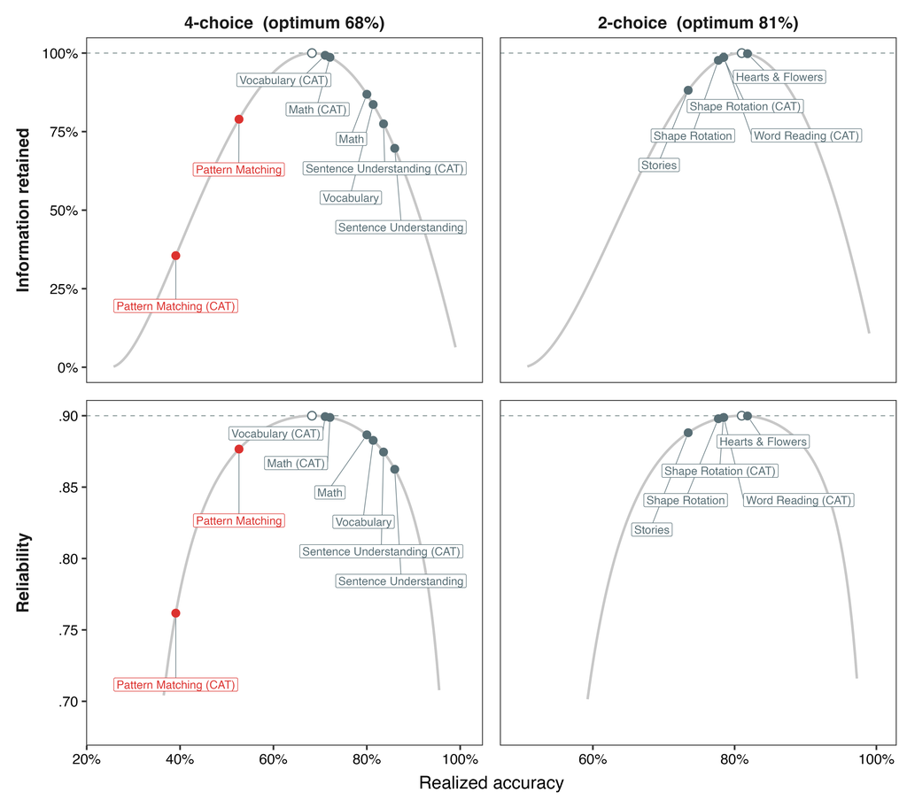

Figure 1: **Missing the information optimum is expensive in information and much cheaper in reliability.** One column per response format; open circles mark each format’s optimum, and the dashed line is the ceiling each currency can reach. All 15 calibrated task × variant cells appear in Table 1; the two formats shown here carry every deployed CAT. Realized accuracy is run-weighted (the mean of run means). Source: four pilot sites — Bogotá, rural Colombia, Leipzig, Western — 18,774 clean runs after the pipeline’s own exclusions. Same & Different is excluded throughout: its realized accuracy pools dependent selections and its chance level matches no guessing model. Pattern Matching in red. Script 87.

```r
include_graphics(file.path(PROJ, "figures/87_price_two_currencies.png"))
```

The same cells as numbers, so the size of each miss is legible. **“Off by”** is the gap in percentage points between what a task realized and its own optimum; **“effective items”** is the median test length multiplied by the information retained — the length a perfectly targeted test would need to measure as precisely.

```r
read_csv(file.path(PROJ, "processed_data/87_placement_all.csv"), show_col_types = FALSE) |>
  transmute(Task = task, Mode,
            Format = recode(as.character(g_use), `0` = "no guessing",
                            `0.25` = "4-choice", `0.33` = "3-choice",
                            `0.5` = "2-choice"),
            Realized = sprintf("%.0f%%", 100 * realized_acc),
            `Own optimum` = sprintf("%.0f%%", 100 * p_star),
            `Off by` = sprintf("%+.0f", off_points),
            `Info kept` = sprintf("%.0f%%", 100 * info_kept),
            Items = median_trials,
            `Effective items` = sprintf("%.0f", eff_items),
            Reliability = sprintf("%.3f", reliability)) |>
  kb(align = "lllrrrrrrr")
```

| Task | Mode | Format | Realized | Own optimum | Off by | Info kept | Items | Effective items | Reliability |
| --- | --- | --- | --- | --- | --- | --- | --- | --- | --- |
| Hearts & Flowers | non-adaptive | 2-choice | 82% | 81% | +1 | 100% | 60 | 60 | 0.900 |
| Memory | non-adaptive | no guessing | 70% | 50% | +20 | 84% | 20 | 17 | 0.883 |
| Math | CAT | 4-choice | 72% | 68% | +4 | 99% | 40 | 39 | 0.899 |
| Math | non-adaptive | 4-choice | 80% | 68% | +12 | 87% | 90 | 78 | 0.887 |
| Pattern Matching | CAT | 4-choice | 39% | 68% | -29 | 36% | 31 | 11 | 0.762 |
| Pattern Matching | non-adaptive | 4-choice | 53% | 68% | -16 | 79% | 22 | 17 | 0.877 |
| Shape Rotation | CAT | 2-choice | 78% | 81% | -2 | 99% | 27 | 27 | 0.899 |
| Shape Rotation | non-adaptive | 2-choice | 78% | 81% | -3 | 98% | 67 | 65 | 0.898 |
| Sentence Understanding | CAT | 4-choice | 84% | 68% | +15 | 77% | 40 | 31 | 0.875 |
| Sentence Understanding | non-adaptive | 4-choice | 86% | 68% | +18 | 70% | 86 | 60 | 0.862 |
| Vocabulary | CAT | 4-choice | 71% | 68% | +3 | 99% | 46 | 46 | 0.899 |
| Vocabulary | non-adaptive | 4-choice | 81% | 68% | +13 | 84% | 122 | 102 | 0.883 |
| Stories | non-adaptive | 2-choice | 73% | 81% | -7 | 88% | 28 | 25 | 0.888 |
| Language Sounds | non-adaptive | 3-choice | 67% | 73% | -6 | 96% | 20 | 19 | 0.896 |
| Word Reading | CAT | 2-choice | 78% | 81% | -2 | 99% | 120 | 118 | 0.899 |

Table 1: Every calibrated task × variant cell against its own format’s information optimum, sorted by battery order. Four pilot sites, 18,774 clean runs. Reliability is from a .90 reference at fixed test length. Script 87.

- **Being non-adaptive is not the problem.** Hearts & Flowers, a fixed form, is the best-targeted cell in the battery: 82% against an 81% optimum.
- **Adaptivity does not reliably improve targeting.** The CAT beats the fixed form for Math and Vocabulary, ties for Shape Rotation and Sentence Understanding, and is far worse for Pattern Matching.
- **Two cells are meaningfully off.** Pattern Matching CAT is 29 points too hard. Sentence Understanding is 15–18 points too easy in both variants.

## What the two currencies mean

The two rows of Figure 1 can look like they disagree — Pattern Matching’s CAT loses two-thirds of its information but only .14 of reliability — so it is worth being explicit about what each one is measuring.

**Fisher information is, in practice, how many items’ worth of measurement a trial buys.** It adds up over items and it is the reciprocal of squared standard error. So “36% of information retained” is literal: Pattern Matching’s 31 items measure like 11, and to recover the precision perfect targeting would give at that length you would need 86 items.

**Reliability is a ratio** — true-score variance over true-score plus error variance — and it is bounded above by 1. That bound is what compresses it. At r = .90 the error variance is one-ninth of the true variance; tripling the error variance makes it one-third, and the ratio only falls to .75. The exchange rate between the two is steep: **you can triple a child’s error variance and lose only about .14 of reliability.**

One situation, five true statements about Pattern Matching’s CAT:

| Question | Currency | Answer |
| --- | --- | --- |
| Are we wasting the child’s time? | information | **64% of it, in that task** |
| How wide are the error bars on one child? | standard error | **1.68× wider** |
| How long would the test need to be to recover? | effective length | 31 items → **86** |
| How much does this hurt a group analysis? | reliability | .90 → **.76**; roughly 18% more children for the same power |
| How does it feel to the child? | success rate | **39%; 31–33% at ages 5–7** |

The .90 anchor is generous. Measured empirically under the core-tasks paper’s own selected models, Pattern Matching’s reliability is .62 and Hearts & Flowers’ is .43 (script 68), so the reliability column understates the real losses.

## The same reliability data, without the ceiling

Because the compression in the bottom row of Figure 1 comes from reliability’s upper bound rather than from anything about the tasks, it is worth seeing the same numbers expressed in a form that has no ceiling. Figure 2 plots exactly the same information as that row, re-expressed as the **standard error of a child’s ability estimate, as a multiple of what a perfectly targeted test of the same length would give**. Reliability and this multiple are the same quantity under a monotone transformation, so no cell moves relative to any other; only the scale changes.

Two things follow from that scale. It is a ratio, so **the optimum sits at exactly 1× and equal vertical distances are equal multiplicative penalties** — hence the log axis. And because it is unbounded, the cost of a large miss is no longer squeezed toward a wall.

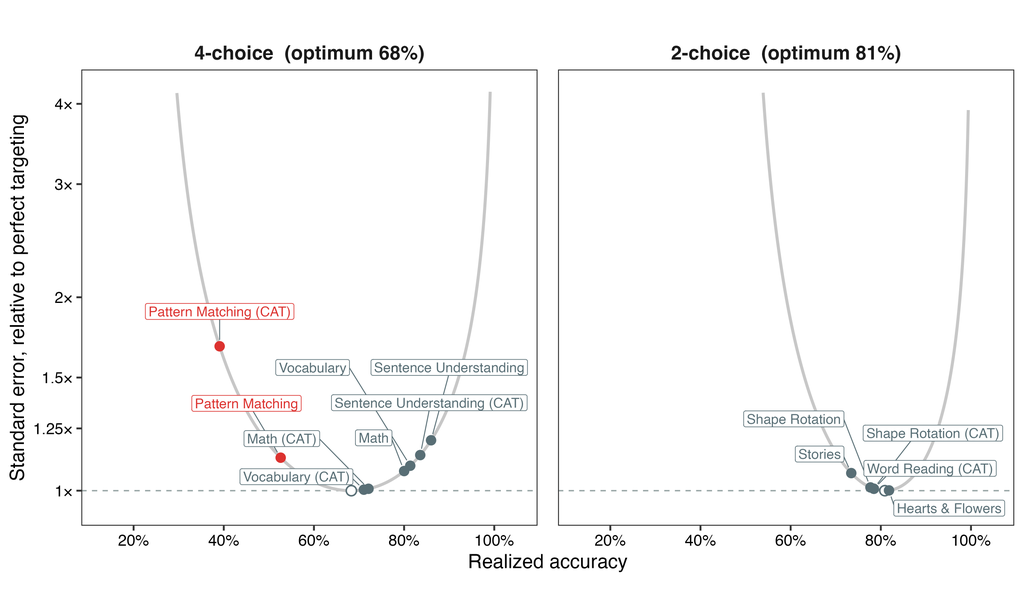

Figure 2: **The same placement as Figure 1, in multiples of error rather than reliability.** The y-axis is the standard error of a child’s ability estimate divided by the standard error a perfectly targeted test of the same length would give — equivalently, one over the square root of the information retained. Log scale, so the optimum (open circle) sits at exactly 1× and equal distances are equal multiplicative penalties. Same cells, same realized accuracies, and the same four pilot sites and 18,774 clean runs as Figure 1. Pattern Matching in red. Script 92.

```r
include_graphics(file.path(PROJ, "figures/92_relative_error.png"))
```

On this scale the basin is close to symmetric near the bottom: on a 4-choice task, being 10 points too hard and 10 points too easy both cost 1.05×, and at 20 points off it is 1.22× against 1.28×. The arms separate only at the extremes, where the too-easy side turns up much faster — 30 points too hard is 1.75×, 30 points too easy is 3.06× — because 100% correct is a wall while the hard side is cushioned by the guessing floor.

The battery’s actual spread: **Pattern Matching’s CAT at 1.68×**, Sentence Understanding at 1.20× and 1.14×, Pattern Matching’s fixed form at 1.13×, and every remaining cell between 1.00× and 1.09×.

## Pattern Matching: the bank problem

Before pricing an easier target, it is worth stating plainly what is wrong with Pattern Matching, because the rest of the document turns on it. The task is not mis-tuned by a few points — it is serving items **harder** than the children, and it is the only task in the battery that does.

- **It realizes 39% correct against a 68% optimum**, and **ages 5–7 sit at 31–33%**, barely above the 25% a four-option guess gives.
- **It is the only adaptive task serving items above the child**, by a median 2.4 logits. Across every site that has run it, the median child sits at **θ = −1.40** while the median item the CAT can reach sits at **b = +2.18**.
- **The cause is the bank, not the algorithm.** The CAT’s own trace shows its ability estimate flat near −2.3 logits while the difficulty it serves climbs from +0.7 to +2.1: it knows where the child is and has nothing to send there. The median child has **six items easier than they are, out of the 77 the CAT draws on**.

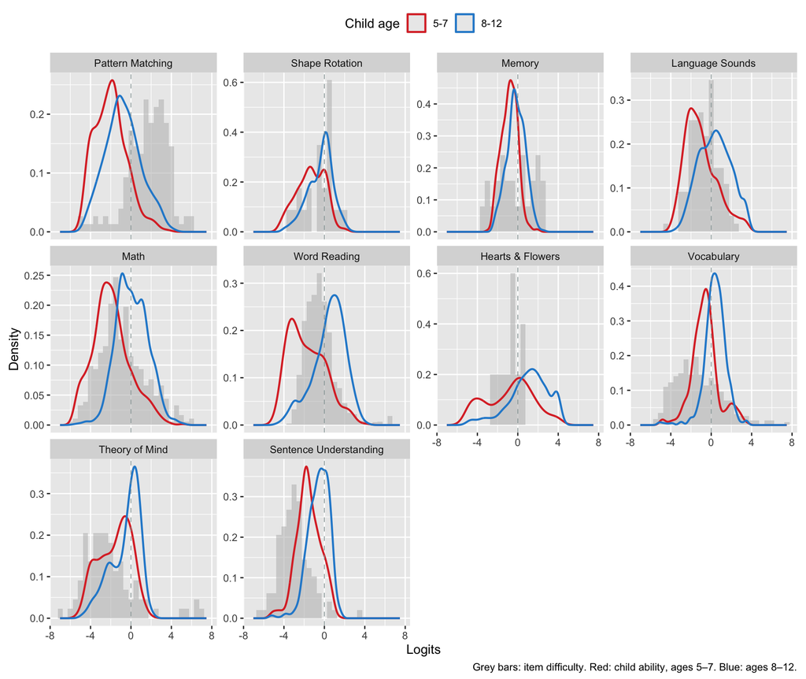

Figure 3: **Pattern Matching is the only task whose item bank sits above its children — and it is worst for the youngest.** Item-bank difficulty (grey bars, density) against child ability split by age — red = ages 5–7, blue = ages 8–12 — for every calibrated task, in logits; panels ordered by the offset between item and child medians. Dashed line at 0 is the calibration-sample average; items and children share the logit scale, so a bar to the right of a line is an item harder than that child. Child ability is one per-run θ estimate; runs per task × age band range from ~310 to ~1,700. Same & Different excluded (yoked design). Source: 93_bank_age.csv — item parameters in the current scoring registry against scored child abilities, four pilot sites. Script 93.

```r
ba <- read_csv(file.path(PROJ, "processed_data/93_bank_age.csv"),
               show_col_types = FALSE) |>
  mutate(Task = unname(task_name[task_id]))
ord <- ba |>
  mutate(grp = if_else(what == "item difficulty", "item", "child")) |>
  group_by(Task, grp) |> summarise(m = median(value), .groups = "drop") |>
  pivot_wider(names_from = grp, values_from = m) |>
  mutate(offset = item - child) |> arrange(desc(offset))
ba <- ba |> mutate(Task = factor(Task, levels = ord$Task))
kids <- ba |> filter(what != "item difficulty") |>
  mutate(age = factor(what, levels = c("5-7", "8-12")))
ggplot() +
  geom_histogram(data = filter(ba, what == "item difficulty"),
                 aes(value, after_stat(density)), binwidth = .5,
                 fill = "grey75", alpha = .6) +
  geom_density(data = kids, aes(value, colour = age), linewidth = .8) +
  geom_vline(xintercept = 0, colour = GREY, linewidth = .3, linetype = "dashed") +
  scale_colour_manual(values = c(`5-7` = RED, `8-12` = BLUE), name = "Child age") +
  facet_wrap(~ Task, ncol = 4, scales = "free_y") +
  labs(x = "Logits", y = "Density",
       caption = "Grey bars: item difficulty. Red: child ability, ages 5–7. Blue: ages 8–12.") +
  theme(aspect.ratio = 1, legend.position = "top")
```

Section 5 sets this out in full — the item-difficulty-against-ability counts and which of the three MaRs-IB item sets actually reach the CAT. The point for the next section is only this: the miss is real and large, so what a deliberately easier target would cost is not an academic question.

## What a deliberately easier target would cost

Since running easier costs measurement precision, the practical question is how much. The table below answers it for the two tasks most likely to be adjusted. It holds test length fixed and asks: **if the CAT deliberately aimed at a success rate above the information optimum, what would we give up?**

The three cost columns are the same quantity in the three currencies used above, so they can be read against each other:

- **Info kept** — the share of the information perfect targeting would give (Figure 1, top row).
- **Reliability** against the .90 reference (Figure 1, bottom row).
- **SE multiple** — each child’s standard error as a multiple of what perfect targeting would give (Figure 2), where 1.00× is the optimum.
- **Effective items kept** — the median test length multiplied by the information retained: how many perfectly-targeted items the test still measures like, out of its actual length.

```r
read_csv(file.path(PROJ, "processed_data/90_easier_targets.csv"), show_col_types = FALSE) |>
  filter(task %in% c("Pattern Matching", "Shape Rotation")) |>
  transmute(Task = task, Format = format,
            Target = sprintf("%.0f%%", 100 * target),
            `Info kept` = sprintf("%.0f%%", 100 * info_kept),
            Reliability = sprintf("%.3f", reliability),
            `SE multiple` = sprintf("%.2f×", se_mult),
            `Effective items kept` = sprintf("%.0f of %.0f", eff_items, median_trials)) |>
  kb(align = "llrrrrr")
```

| Task | Format | Target | Info kept | Reliability | SE multiple | Effective items kept |
| --- | --- | --- | --- | --- | --- | --- |
| Pattern Matching | 4-choice | 70% | 100% | 0.900 | 1.00× | 31 of 31 |
| Pattern Matching | 4-choice | 75% | 96% | 0.896 | 1.02× | 30 of 31 |
| Pattern Matching | 4-choice | 80% | 87% | 0.887 | 1.07× | 27 of 31 |
| Pattern Matching | 4-choice | 85% | 73% | 0.868 | 1.17× | 23 of 31 |
| Pattern Matching | 4-choice | 90% | 54% | 0.829 | 1.36× | 17 of 31 |
| Pattern Matching | 4-choice | 95% | 30% | 0.727 | 1.84× | 9 of 31 |
| Shape Rotation | 2-choice | 85% | 96% | 0.896 | 1.02× | 26 of 27 |
| Shape Rotation | 2-choice | 90% | 79% | 0.877 | 1.13× | 21 of 27 |
| Shape Rotation | 2-choice | 95% | 47% | 0.810 | 1.45× | 13 of 27 |

Table 2: The cost of aiming above the information optimum, at fixed test length. Reliability is from a .90 reference; the SE multiple is one over the square root of the information kept, the quantity plotted in Figure 2. Analytic — idealized Rasch model with a fixed guessing floor, no data fitting; test lengths are the observed medians from the four pilot sites. Script 90.

The cost depends only on the guessing floor, so it is the same for every 4-choice task: **75% costs 4% of the information and .004 of reliability; 80% costs 13% and .013; 85% costs 27% and .032.** For a 2-choice task, **85% costs 4% and .004; 90% costs 21% and .023.** The first several points are close to free and then the cost accelerates, which puts the decision point in the high seventies rather than at 90%.

# What the Pattern Matching bank looks like

Section Section 4 establishes that Pattern Matching’s CAT runs too hard. This section asks why, by comparing the difficulty of the items available against the ability of the children taking the task. Both are on the same logit scale, so they can be read directly against each other: an item at the child’s own ability gives them about a 50-50 shot before guessing.

```r
read_csv(file.path(PROJ, "processed_data/89_bank_vs_ability.csv"), show_col_types = FALSE) |>
  pivot_wider(names_from = what, values_from = value) |>
  rename(Quantile = q) |> kb(align = "rrrr")
```

| Quantile | children (theta) | calibrated bank (all sets) | items the CAT can reach (set 1) |
| --- | --- | --- | --- |
| 0.00 | -4.86 | -5.12 | -4.39 |
| 0.10 | -3.49 | -0.67 | -0.34 |
| 0.25 | -2.47 | 0.52 | 0.69 |
| 0.50 | -1.40 | 1.97 | 2.18 |
| 0.75 | -0.22 | 3.08 | 3.54 |
| 0.90 | 1.06 | 3.84 | 4.12 |
| 1.00 | 4.28 | 6.00 | 6.00 |

Table 3: Pattern Matching item difficulty against child ability, in logits, at matching quantiles. Children: 1,712 scored runs, median age 9.1, across all eight sites that have administered the task. Items: the calibrated bank in the current scoring registry, and the subset of it that has ever been served in an adaptive run. Script 89.

The median child sits at **θ = −1.40**; the median item the CAT can reach sits at **b = +2.18**. Counting how many items are actually easier than the child:

| Child at | Items easier, of the 77 the CAT reaches | Items easier, of all 151 calibrated |
| --- | --- | --- |
| 10th percentile (θ = −3.49) | 2 | 5 |
| 25th percentile (θ = −2.47) | 4 | 8 |
| **median (θ = −1.40)** | **6** | **11** |

## Which item sets are in play

MaRs-IB ships three item sets. The table below counts, for each one, how many trials it has ever generated, how many of its items carry IRT parameters — a CAT can only select items that have them — and how many the adaptive form has actually served.

```r
read_csv(file.path(PROJ, "processed_data/89_matrix_sets.csv"), show_col_types = FALSE) |>
  transmute(Set = set,
            Trials = format(trials, big.mark = ","),
            `Items seen` = items_seen,
            `Items calibrated` = coalesce(items_calibrated, 0L),
            `Items the CAT serves` = items_served_by_cat,
            `Median difficulty` = med_b,
            `Items below b = −1` = coalesce(n_below_neg1, 0L)) |>
  kb(align = "lrrrrrr")
```

| Set | Trials | Items seen | Items calibrated | Items the CAT serves | Median difficulty | Items below b = −1 |
| --- | --- | --- | --- | --- | --- | --- |
| set1 | 40,612 | 78 | 77 | 78 | 2.18 | 6 |
| set2 | 0 | 0 | 0 | 0 | NA | 0 |
| set3 | 6,132 | 79 | 74 | 0 | 1.58 | 6 |

Table 4: MaRs-IB sets: administered, calibrated, and reachable by the CAT. 46,744 Pattern Matching trials across 1,712 runs and 8 sites, against the item parameters in the current scoring registry. Script 89.

- **Set 2 has never been administered** — zero trials, at any site.
- **Set 3 has been administered at Leipzig only, in non-adaptive form.** 79 items seen, 74 of them already calibrated, and the CAT has served none of them. Every adaptive run in the database draws on set 1 alone.
- **The CAT therefore reaches 77 of the 151 calibrated items**, and its reachable half is the harder half: median b +2.18 against +1.97 for the full calibrated bank.
- **Neither set is built out at the easy end.** Set 1 has 6 items below b = −1 and set 3 has 6 — twelve of 151, for a population whose median child is at −1.40.

# Where the CAT starts every child

A CAT that starts from a poor guess about a child’s ability has to walk toward them, and every trial spent walking is a trial not spent measuring. The table below shows the very first item each task serves, broken out by age band. If the start point adapted to age, `Item b` would fall as the age band gets younger; `Child θ` shows how much it would need to fall.

```r
read_csv(file.path(PROJ, "processed_data/40_ramp.csv"), show_col_types = FALSE) |>
  filter(trial_number == 1) |>
  transmute(Task = if_else(task_id == "egma-math", "Math", "Pattern Matching"),
            `Age band` = age_band, Runs = n,
            `Item b` = round(mean_b, 2), `Child θ` = round(mean_theta, 2),
            `Gap (b − θ)` = round(mean_gap, 2),
            `Expected accuracy` = sprintf("%.0f%%", 100 * mean_p),
            Realized = sprintf("%.0f%%", 100 * acc)) |>
  kb(align = "llrrrrrr")
```

| Task | Age band | Runs | Item b | Child θ | Gap (b − θ) | Expected accuracy | Realized |
| --- | --- | --- | --- | --- | --- | --- | --- |
| Math | 5-6 | 173 | -1.56 | -2.67 | 1.12 | 55% | 51% |
| Math | 7-8 | 355 | -1.36 | -1.33 | -0.03 | 65% | 63% |
| Math | 9-12 | 626 | -1.33 | 0.00 | -1.33 | 74% | 74% |
| Pattern Matching | 5-6 | 118 | 0.82 | -2.74 | 3.56 | 41% | 36% |
| Pattern Matching | 7-8 | 188 | 0.61 | -2.20 | 2.81 | 45% | 41% |
| Pattern Matching | 9-12 | 345 | 0.76 | -1.44 | 2.20 | 48% | 46% |

Table 5: The first item served, by task and age band. `Gap` is the item’s difficulty minus the child’s estimated ability, in logits; positive means the item is above the child. `Expected accuracy` is what the model predicts for that gap including guessing. Adaptive runs, four pilot sites. Script 40.

`Item b` barely moves across age bands while `Child θ` moves by two logits. Pattern Matching opens every child on an item at **b ≈ +0.7**: for a 9–12 year old that is 2.2 logits too hard, and for a 5–6 year old **3.56 logits too hard**, giving 41% expected accuracy on a 4-choice item and 36% realized. It does not recover quickly — by the fifth trial the gap for 5–6 year olds is still 3.67.

Math is the contrast case. Its bank runs down to b = −6 with 65 items below −3, so the walk down succeeds — but it still spends trials doing it.

# Where children check out

The disengagement measure here is **NT10**: a trial counts as a rapid guess if the response arrives faster than 10% of that item’s own mean response time, floored at 250 ms and capped at 10 seconds. Making the threshold item-relative rather than absolute is what keeps a genuinely fast answer on an easy item from being scored as a lapse.

The figure plots that rate against how hard the trial was for that child — specifically the model’s expected accuracy for the item served, which folds together the item’s difficulty and the child’s estimated ability. These are absolute rates, so the height of each line is directly comparable across tasks.

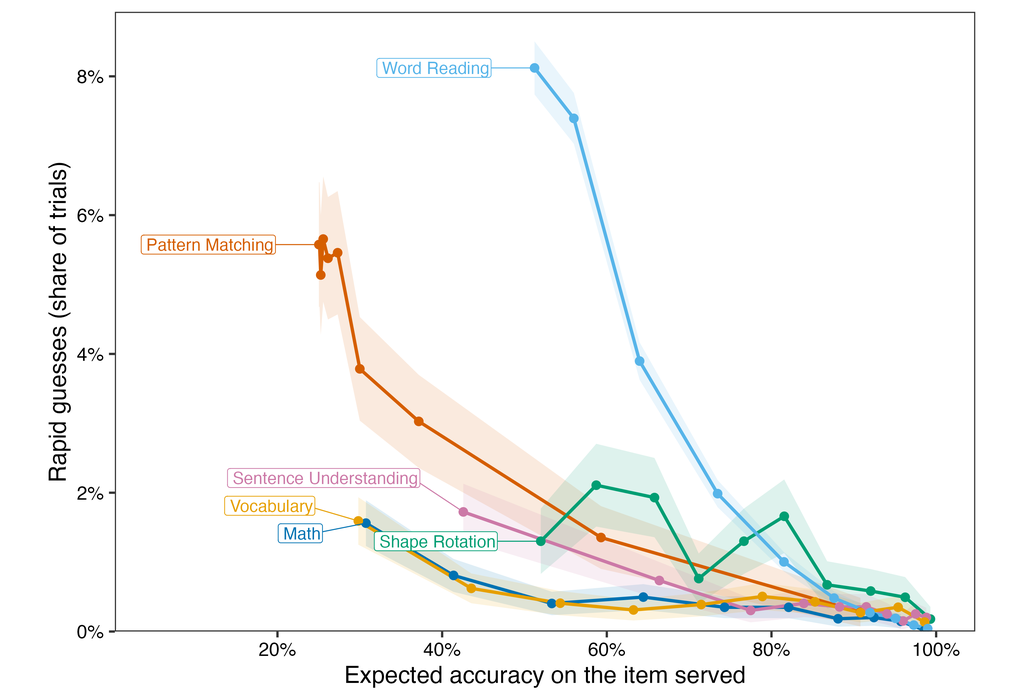

```r
include_graphics(file.path(PROJ, "figures/91_rapid_cat.png"))
```

```r
ov <- read_csv(file.path(PROJ, "processed_data/91_rapid_overall.csv"), show_col_types = FALSE)
bn <- read_csv(file.path(PROJ, "processed_data/91_rapid_by_bin.csv"), show_col_types = FALSE)
ov |> left_join(bn |> group_by(task) |>
                  summarise(hardest = y[which.min(x)], easiest = y[which.max(x)],
                            .groups = "drop"), by = "task") |>
  transmute(Task = task, Runs = runs, Trials = format(trials, big.mark = ","),
            Overall = sprintf("%.1f%%", 100 * rapid_rate),
            `Hardest decile` = sprintf("%.1f%%", 100 * hardest),
            `Easiest decile` = sprintf("%.1f%%", 100 * easiest)) |>
  kb(align = "lrrrrr")
```

| Task | Runs | Trials | Overall | Hardest decile | Easiest decile |
| --- | --- | --- | --- | --- | --- |
| Pattern Matching | 743 | 25,104 | 4.1% | 5.6% | 0.3% |
| Word Reading | 1676 | 195,289 | 2.3% | 8.1% | 0.0% |
| Shape Rotation | 811 | 22,282 | 1.1% | 1.3% | 0.2% |
| Vocabulary | 1115 | 51,451 | 0.5% | 1.6% | 0.1% |
| Sentence Understanding | 1002 | 39,443 | 0.5% | 1.7% | 0.2% |
| Math | 1315 | 54,415 | 0.5% | 1.6% | 0.0% |

Table 6: Rapid-guessing rate per CAT task, adaptive runs only, four pilot sites. ‘Hardest’ and ‘easiest’ are the first and last deciles of expected accuracy within each task. Script 91.

A between-children pattern like this could just mean that struggling children both see harder items and guess more. Four analyses in the long document rule that out by holding the child fixed:

- Within run, controlling for position in the run, a trial’s expected accuracy moving from 1 to 0 adds **1.3 percentage points** of rapid-guess probability on a base rate near 1.5% (P < .001). The effect is negative in 22 of 26 task × variant × age cells, and null exactly where it should be — Word Reading and Hearts & Flowers, the two tasks already serving at or below the child.
- **Failure itself does the damage, not only difficulty.** Holding the difficulty of the previous three trials fixed, which makes their outcomes as-good-as-random, each additional failure among them adds **+0.3 / +1.1 / +2.0 percentage points** of rapid-guess risk at one, two and three wrong.
- The preceding-streak effect survives position control with only **5% attenuation**: +1.4 points at three or more consecutive errors.
- Along a streak, wrong answers speed up three times faster than correct ones, so the gap that marks an engaged error collapses from **0.28 to 0.02** within-child SD.

The same dose-response, pooled across the battery and with ability held constant, is the single clearest picture of the effect. The grey line is the raw between-children relationship — steeper and non-monotone because hard trials belong disproportionately to struggling children. The blue line removes each run’s own mean (run fixed effects), so it is the within-child quantity: harder trials draw more rapid guessing from the *same* child.

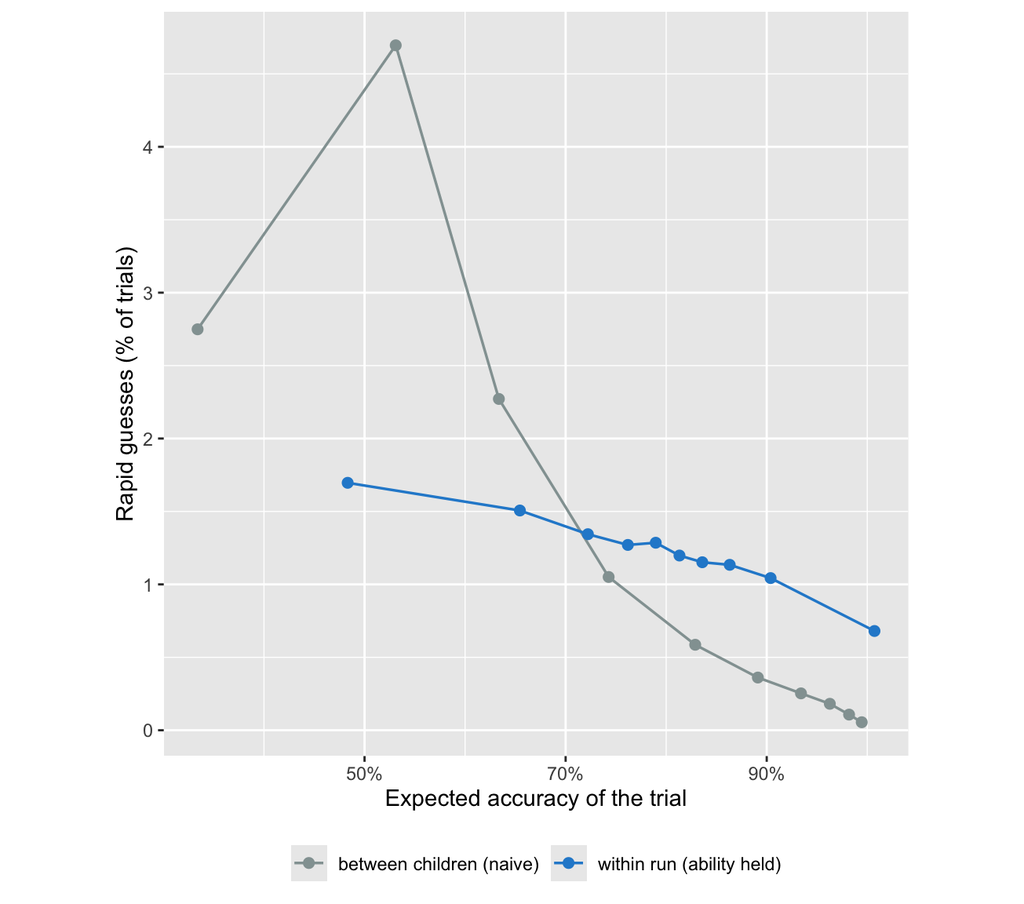

Figure 5: **Within a child, rapid guessing rises as the trial gets harder.** P(rapid guess) by decile of the trial’s expected accuracy, pooled across the battery: 713,953 trials from eight tasks (both variants, all sites and ages; clean runs with ≥10 usable trials; Language Sounds, Memory, Sentence Reading and Same & Different excluded for the reasons in Figure 4). Grey: the raw between-children relationship (all variation, including ability). Blue: within run — each run’s mean removed, recentered at the grand mean — the defensible quantity. The naive curve’s hump near 50% is format composition at the guessing floor. Scripts 76/82/84.

```r
read_csv(file.path(PROJ, "processed_data/82a_bins.csv"), show_col_types = FALSE) |>
  ggplot(aes(x, y, colour = series)) +
  geom_line(linewidth = .6) + geom_point(size = 2) +
  scale_colour_manual(values = c(`between children (naive)` = GREY,
                                 `within run (ability held)` = BLUE), name = NULL) +
  scale_x_continuous("Expected accuracy of the trial",
                     labels = scales::percent_format(1)) +
  scale_y_continuous("Rapid guesses (% of trials)") +
  theme(aspect.ratio = 1, legend.position = "bottom")
```

Splitting the same within-run relationship by age band shows where the cost lands. This pools the per-task age curves (each task × variant demeaned within run, then averaged across tasks weighted by trial count), so it is an exploratory summary rather than a fitted model: **5–7 year olds (red) guess rapidly at roughly twice the rate of 8–12 year olds (blue) at every difficulty, and both bands rise as trials get harder.**

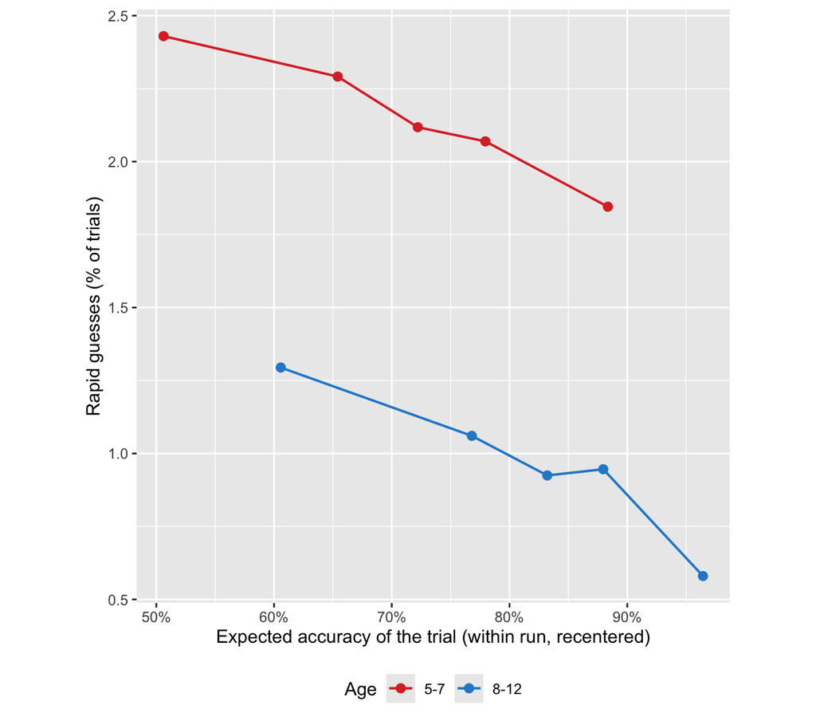

```r
read_csv(file.path(PROJ, "processed_data/83_cell_bins.csv"), show_col_types = FALSE) |>
  group_by(age_band, q) |>
  summarise(x = weighted.mean(x, n_trials), y = weighted.mean(y, n_trials),
            .groups = "drop") |>
  ggplot(aes(x, y, colour = age_band)) +
  geom_line(linewidth = .7) + geom_point(size = 2.2) +
  scale_colour_manual(values = c(`5-7` = RED, `8-12` = BLUE), name = "Age") +
  scale_x_continuous("Expected accuracy of the trial (within run, recentered)",
                     labels = scales::percent_format(1)) +
  scale_y_continuous("Rapid guesses (% of trials)") +
  theme(aspect.ratio = 1, legend.position = "bottom")
```

## What a rescue rule could do

One response to a child crashing out is to hand them an easy item after a run of errors. The table replays every observed run, resetting the error counter each time such a rule would have fired, and asks what it would cost and buy. It is a replay rather than an experiment, and it assumes the rescue fully resets the child’s state — the most favourable assumption available — so the magnitudes are an upper bound.

The cost is carried in the same three currencies as Section 4. A rescue item is one served deliberately below the child, so it buys less information than the item it displaces; **information cost** is that shortfall as a share of the task’s total, **reliability** is what a task at .90 would fall to, and **SE multiple** is the widening of each child’s standard error, where 1.00× is unchanged. The last two columns are the benefit: the rapid-guessing rate before and after, and the drop as a share of the original rate.

```r
read_csv(file.path(PROJ, "processed_data/60_counterfactual.csv"), show_col_types = FALSE) |>
  filter(!is.na(k)) |>
  transmute(`Trigger (k errors)` = k,
            `Fires per run` = sprintf("%.2f", rescues_per_run),
            `Share of trials` = sprintf("%.1f%%", fires_pct),
            `Information cost` = sprintf("%.1f%%", info_cost_pct),
            Reliability = sprintf("%.4f", reliability),
            `SE multiple` = sprintf("%.3f×", se_mult),
            `Rapid guessing` = sprintf("%.2f%% → %.2f%%", 100 * rapid_obs, 100 * p_rapid_cf),
            `Relative drop` = sprintf("−%.0f%%", pct_drop)) |> kb(align = "rrrrrrrr")
```

| Trigger (k errors) | Fires per run | Share of trials | Information cost | Reliability | SE multiple | Rapid guessing | Relative drop |
| --- | --- | --- | --- | --- | --- | --- | --- |
| 1 | 14.80 | 25.5% | 4.0% | 0.8963 | 1.020× | 1.44% → 0.81% | −43% |
| 2 | 3.86 | 6.7% | 1.0% | 0.8991 | 1.005× | 1.44% → 1.14% | −21% |
| 3 | 1.47 | 2.5% | 0.4% | 0.8996 | 1.002× | 1.44% → 1.28% | −11% |
| 4 | 0.67 | 1.2% | 0.2% | 0.8998 | 1.001× | 1.44% → 1.36% | −5% |
| 5 | 0.36 | 0.6% | 0.1% | 0.8999 | 1.000× | 1.44% → 1.40% | −3% |

Table 7: A rescue item after k consecutive errors: how often it fires, what it costs, and how much rapid guessing it removes. Counterfactual replay over 7,129 runs and 418,065 trials from the four pilot sites; assumes a full state reset and unchanged later accuracy. Reliability and the SE multiple are converted from the information cost exactly as in Table 2. Script 60.

At k = 3 the rule fires on 2.5% of trials and removes 11% of rapid guessing, for 0.4% of the information — which is **.900 → .8996 in reliability and 1.002× in standard error**, a cost too small to appear at the precision anyone reports. At k = 1 it removes 43% of rapid guessing, but fires on a quarter of all trials and still only reaches 1.02× on error. The binding constraint is not the price: most rapid guessing never follows a streak at all, which is the ceiling on what a rule of this shape can achieve.

# The same problem one age band down

The downward extension pushes the core tasks below the 5–12 range they were built for. If the diagnosis in Section 5 is right — that the trouble is bank coverage at the easy end — then math should show the same pattern wherever the children are young enough. It does.

```r
read_csv(file.path(PROJ, "processed_data/88_math_by_site.csv"), show_col_types = FALSE) |>
  transmute(Site = site_ds |> str_replace_all("pilot_|partner_|rfp1_", "") |>
              str_replace_all("_main|_us|_de|_co|_ca|_ar|_gb|_intl", ""),
            Runs = runs, `Median age` = round(med_age, 1),
            `Age range` = sprintf("%.1f–%.1f", min_age, max_age),
            `Median items` = med_trials,
            Realized = sprintf("%.0f%%", 100 * realized_acc)) |> kb(align = "lrrlrr")
```

| Site | Runs | Median age | Age range | Median items | Realized |
| --- | --- | --- | --- | --- | --- |
| bostonchildrens | 21 | 4.8 | 2.2–5.9 | 17 | 50% |
| mpib_ys | 67 | 5.8 | 4.5–8.4 | 23 | 52% |
| mpib | 113 | 6.9 | 6.4–7.6 | 33 | 65% |
| utdt | 24 | 7.0 | 6.4–8.1 | 28 | 68% |
| uniandes_rural | 912 | 9.7 | 5.1–15.3 | 40 | 71% |
| mpieva | 79 | 8.9 | 5.3–11.1 | 34 | 73% |
| uniandes_bogota | 591 | 9.7 | 4.9–14.0 | 41 | 74% |
| western | 296 | 8.5 | 5.0–14.2 | 39 | 74% |
| sheffield | 38 | 7.9 | 6.3–10.0 | 30 | 83% |

Table 8: Math realized accuracy in adaptive runs, per site, sorted by accuracy. Runs with at least 10 trials, after each dataset’s own exclusion flags. The 4-choice optimum is 68%. Script 88.

Boston Children’s runs at **50%**, the lowest in the database — but that is about who it tests, not about the site. Splitting by age year and comparing the downward-extension sites against the main sites separates the two:

```r
read_csv(file.path(PROJ, "processed_data/88_math_by_age.csv"), show_col_types = FALSE) |>
  transmute(Arm = arm, Age = age_yr, Runs = runs,
            Realized = sprintf("%.0f%%", 100 * realized_acc)) |>
  pivot_wider(names_from = Arm, values_from = c(Runs, Realized)) |> kb()
```

| Age | Runs_downward extension | Runs_main sites | Realized_downward extension | Realized_main sites |
| --- | --- | --- | --- | --- |
| 4 | 7 | 7 | 46% | 48% |
| 5 | 8 | 126 | 58% | 52% |
| 6 | NA | 289 | NA | 63% |
| 7 | NA | 302 | NA | 70% |
| 8 | NA | 267 | NA | 73% |
| 9 | NA | 290 | NA | 74% |
| 10 | NA | 258 | NA | 76% |
| 11 | NA | 255 | NA | 76% |
| 12 | NA | 189 | NA | 77% |
| 13 | NA | 38 | NA | 76% |
| 14 | NA | 10 | NA | 78% |

Table 9: Math realized accuracy by age year, downward-extension sites (Boston Children’s, langcog, sparklab) against the main pilot sites. Adaptive runs, cells with at least 5 runs. Script 88.

The mechanism matches Section 5 one level further down. Stanford’s sparklab site runs a fixed-form downward extension — 490 clean runs, ages 3.3 to 4.9, median 29 items, 56% realized — and comparing its item list against the pool the CAT draws on:

- It serves **124 math items, 8 of which appear in no other dataset**: `math_count_1`, `math_count_4`, `math_identify_3`, `math_ns_identify_2`, and four `math_ns_compare_*` items.
- **Within the same children, those 8 run at 75% accuracy against 49% on the other 116.** They are the easy items, and they work.
- **Boston Children’s serves 107 math items and none of the 8**, despite running the newest task versions and drawing on the same nominal item bank.
- In the current scoring registry the calibrated math bank is **365 items, containing 0 of the 8**.

So the easy preschool items exist and are administrable, but carry no IRT parameters, and the adaptive algorithm cannot select an item it has no parameters for.

# The Leipzig test–retest

Leipzig (the mpieva site) administered Pattern Matching twice, about three months apart, on two different item sets: the deployed **original bank** (MaRs-IB set 1) and a **retest bank** (MaRs-IB set 3). The two are **cloned parallel forms** — the *same* item templates rendered in different shapes — so they are **equal in difficulty by design** (Chierchia et al. 2019 report no accuracy difference between the shape sets), and a child’s second score cannot be inflated by remembering specific items. **150 children took both** (149 have a scored run on each); the median gap between sittings is 0.3 years. This is the one place in the data with a second look at the same children on an equally-hard parallel form.

## Both banks sit well above the children

Because the two banks are cloned, the item difficulty is the same. On the T1 (set-1) scale — b is difficulty in logits, the same log-odds scale as child ability, higher meaning harder — the median item sits at **+2.18 logits**, well above where the children are, and the youngest furthest below. (The scoring registry happens to calibrate the set-3 items about 0.7 logits *easier*, but that reflects *who* took set 3 — its takers were abler and got the equal-difficulty items right more often — not a real difference in the items. The figure and table below use the T1/cloned difficulty.)

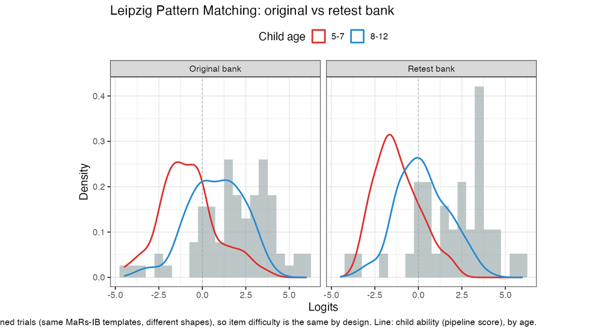

Figure 7: Item difficulty on the T1 (set-1) scale (grey bars) against child ability split by age (red 5–7, blue 8–12), for the original and retest Pattern Matching banks at Leipzig. The banks are cloned trials (same MaRs-IB templates, different shapes), so item difficulty is the same by design — the retest items are shown at their set-1 clone’s difficulty. Ability is the pipeline score; unit of observation is the run. Source: mpieva per-site processed scores and `item_parameters_current`. Script 94.

```r
include_graphics(file.path(PROJ, "figures/94_leipzig_retest.png"))
```

| Bank | Median item b (T1 scale) | Ages 5–7 | Ages 8–12 |
| --- | --- | --- | --- |
| Original | +2.18 | −0.89 | +0.81 |
| Retest | +2.40 | −1.52 | +0.06 |

Table 10: Median item difficulty on the T1 (set-1) scale and median child ability (pipeline score, logits) by age band. Item difficulty is essentially the same across banks (cloned trials); on both, the typical child sits ~2–3 logits below the typical item. The by-bank ability gap here mixes the two sittings’ different populations — the clean within-child comparison is the scatter below.

## The score is moderately stable, and drops slightly at retest

Comparing each child’s original-bank score (**T1**, their first sitting) against their retest-bank score (**T2**, about three months later):

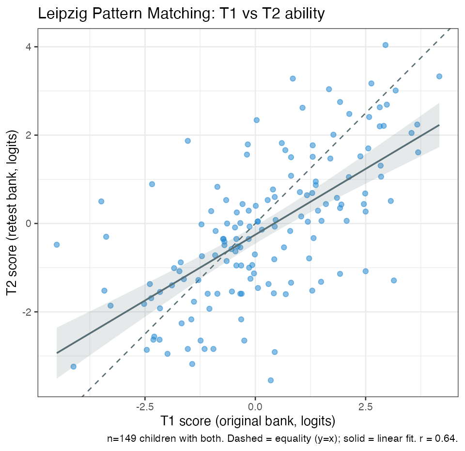

Figure 8: Each child’s original-bank score (T1) against retest-bank score (T2), in logits, for the 149 children with a score on both. Dashed line is equality (y = x); solid is the linear fit. Pipeline ability score. Source: mpieva per-site processed scores. Script 112.

```r
include_graphics(file.path(PROJ, "figures/112_T1_vs_T2_scatter.png"))
```

- **Test–retest correlation r = 0.64** across the 149 children — moderate for a short, hard test.
- The fit is **flatter than the equality line** (slope **0.60**) — but that slope is *exactly* the regression-to-the-mean benchmark (r × SD₂/SD₁ = 0.60), so the tilt is just RTM and carries no information. Each score has a standard error near 0.8 logits, which is what produces it.
- **The whole cloud also shifts down**, **mean(T2 − T1) = −0.33 logits**. Regression to the mean moves the spread, not the mean, so this shift is **not RTM**. Read the logit *size* loosely, though: the retest (T2) scores are on the set-3 scale, which the registry calibrates ~0.7 logits too easy, so some of this θ shift is that scale rather than the children. The calibration-free measure of the dip is the ~6-percentage-point drop in accuracy on the *identical* cloned items (below) — that one is real, and notable because the children are three months older and should, if anything, have improved.

## On the retest the children answer faster and guess a little more

Two behavioural differences on the retest, both plotted against **T1 ability** (each child’s first-sitting score, so the retest panel is not contaminated by its own guessing). Response time first:

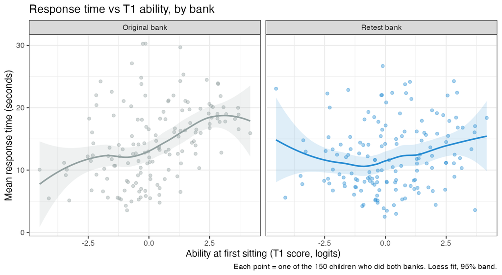

Figure 9: Mean response time per item (seconds) against ability at the first sitting (T1 score, logits), for the 150 children who took both banks; one point per child per bank, loess fit with 95% band. Source: mpieva runs, `trials_clean` cache. Script 112.

```r
include_graphics(file.path(PROJ, "figures/112_rt_T1_faceted.png"))
```

On the **original** bank, response time **rises with ability** — the more able children deliberate longer, up to about 18 seconds an item. On the **retest** that relationship **flattens** to roughly 10–15 seconds across the range: the able children stop slowing down.

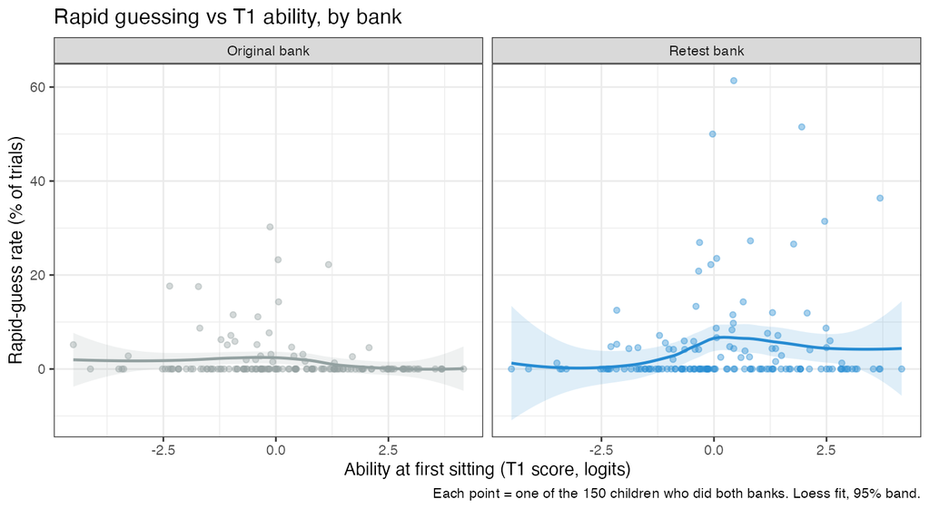

Figure 10: Rapid-guess rate (NT10: a response faster than 10% of that item’s mean response time) against ability at the first sitting (T1 score, logits), for the 150 children who took both banks; one point per child per bank, loess fit with 95% band. Script 112.

```r
include_graphics(file.path(PROJ, "figures/112_rapid_T1_faceted.png"))
```

## What this shows

Because the forms are equal-difficulty clones, the “different bank” and “second sitting” explanations collapse into one: this **is** a within-child retest effect. The clean, item-anchored fact is that on the **identical cloned items** the same children scored about **6 percentage points lower at retest** (53.2% → 47.5%, paired P < .001) — a real second-sitting dip, not an artifact of an easier form. It surfaces as the ~0.3-logit score drop (which, again, is a real dip, **not** regression to the mean), and only about **12%** of it is carried by rapid-guess trials — the rest is a broad, normally-paced underperformance, alongside the response-time flattening above: on the retest the abler children stop deliberating.

Two caveats. The scoring registry calibrates the set-3 items about 0.7 logits easier than their set-1 clones; that mostly reflects abler set-3 takers and largely washes out of the score (group-mean centering absorbs a uniform difficulty offset), but it would bias any item-by-item comparison of the two banks and is worth checking upstream. And the effects are small on a noisy measure — so read this as a real but modest retest dip, not a headline result.

# Data

Realized accuracy, rapid guessing, the ramp and the rescue replay come from the four pilot sites — Bogotá, rural Colombia, Leipzig and Western Ontario — pulled 2026-07-17, giving 18,774 clean runs after the pipeline’s own exclusions. That cache is two data updates behind: rural Colombia has 47% more trials available than in our copy and Western 27% more, and eight further sites are absent from it. Re-running the scoring and exclusion pipeline on the current pull has not been done, so those sections would move somewhat on a refresh.

The bank composition, downward-extension, and Leipzig test–retest sections use the per-site processed datasets — pulled 2026-08-25 — with item parameters from scoring registry v2.3.

# Open questions in the data

- Are 8 easy math items enough to reach 68% at ages 3–5, or does the downward extension need a purpose-built preschool form? Nothing here settles it.
- How much of Pattern Matching’s shortfall is bank coverage and how much is the start point? The two are confounded in observed data.
- What would a refreshed scoring run on the current data do to Section 4, Section 6 and Section 7?
- Whether the rescue-rule magnitudes survive a real experiment, given that the replay assumes a full state reset.
- Why the scoring registry calibrates MaRs-IB set 3 about 0.7 logits easier than its set-1 clones (Section 9), given the two are equal-difficulty parallel forms — a linking question worth checking in the upstream calibration.